# Evaluating the Business Impact of Artificial Intelligence Adoption Across the Quality Engineering Lifecycle

**Interim Analytical Notebook**  
**Satish Venugopal**  
**Walsh College**  
**QM640: Data Analytics Capstone**  
**Mentor: Ms. Sanhita Karmakar**

## Research Questions

1. **RQ1:** Does AI adoption significantly improve productivity across Quality Engineering activities?
2. **RQ2:** Does AI-generated business value differ across Quality Engineering lifecycle phases?
3. **RQ3:** Which project characteristics and Quality Engineering factors influence productivity improvement?
4. **RQ4:** Can machine-learning models predict productivity improvement and identify priority AI-adoption areas?

The analysis uses a 95% confidence level and a significance threshold of α = .05. Predictive results are interpreted as directional decision support rather than causal evidence or an autonomous investment recommendation.

```python
%matplotlib inline

import warnings
warnings.filterwarnings("ignore")

from pathlib import Path
from itertools import combinations
import math
import re

import numpy as np
import pandas as pd
import matplotlib.pyplot as plt

from IPython.display import display
from scipy import stats
import statsmodels.formula.api as smf
from statsmodels.stats.multitest import multipletests

from sklearn.model_selection import GroupShuffleSplit, GroupKFold, cross_validate
from sklearn.compose import ColumnTransformer
from sklearn.pipeline import Pipeline
from sklearn.preprocessing import OneHotEncoder, StandardScaler
from sklearn.impute import SimpleImputer
from sklearn.linear_model import LinearRegression
from sklearn.ensemble import RandomForestRegressor, GradientBoostingRegressor
from sklearn.metrics import mean_absolute_error, mean_squared_error, r2_score
from sklearn.inspection import permutation_importance

pd.set_option("display.max_columns", 100)
pd.set_option("display.float_format", lambda value: f"{value:,.3f}")

def locate_repository_root():
    current = Path.cwd().resolve()
    candidates = [current, current.parent, current.parent.parent]
    for candidate in candidates:
        if (candidate / "data" / "raw" / "EQEPD_Dataset_v5.xlsx").exists():
            return candidate
    raise FileNotFoundError(
        "Repository root was not found. Run the notebook from the repository "
        "root or from the notebooks folder."
    )

REPO_ROOT = locate_repository_root()
DATA_PATH = REPO_ROOT / "data" / "raw" / "EQEPD_Dataset_v5.xlsx"
PROCESSED_DIR = REPO_ROOT / "data" / "processed"
FIGURES_DIR = REPO_ROOT / "outputs" / "figures"
TABLES_DIR = REPO_ROOT / "outputs" / "tables"

for output_dir in [PROCESSED_DIR, FIGURES_DIR, TABLES_DIR]:
    output_dir.mkdir(parents=True, exist_ok=True)

def save_figure(filename):
    output_path = FIGURES_DIR / filename
    plt.tight_layout()
    plt.savefig(output_path, dpi=300, bbox_inches="tight")
    plt.show()
    plt.close()
    print(f"Saved: {output_path.relative_to(REPO_ROOT)}")

print(f"Repository root: {REPO_ROOT}")
print(f"Dataset: {DATA_PATH.relative_to(REPO_ROOT)}")
```

```
Repository root: C:\Users\DINESH\QM640
Dataset: data\raw\EQEPD_Dataset_v5.xlsx
```

## 1. Data Loading and Initial Profiling

```python
raw_data = pd.read_excel(DATA_PATH, sheet_name="Raw data")
raw_data.columns = [
    re.sub(r"\s+", " ", str(column).replace("\n", " ").strip())
    for column in raw_data.columns
]
data = raw_data.copy()

print(f"Raw observations: {data.shape[0]:,}")
print(f"Raw variables: {data.shape[1]:,}")
display(data.head())
```

```
Raw observations: 459
Raw variables: 24
```

|  | Sprint # | Application_Name | Team_Name | AI Usage Testing Phase (Test Planning) | AI Usage Testing Phase (Test Design) | AI Usage Testing Phase (Automation Development) | AI Usage Testing Phase (Test Execution) | AI Usage Testing Phase (Regression Testing) | AI Usage Testing Phase (Defect Management) | Complexity | User story count | test case count | Baseline effort (Test Planning) | Baseline effort (Test Design) | Baseline effort (Automation Development) | Baseline effort (Test Execution) | Baseline effort (Regression Testing) | Baseline effort (Defect Management) | Actual effort (Test Planning) | Actual effort (Test Design) | Actual effort (Automation Development) | Actual effort (Test Execution) | Actual effort (Regression Testing) | Actual effort (Defect Management) |
| --- | --- | --- | --- | --- | --- | --- | --- | --- | --- | --- | --- | --- | --- | --- | --- | --- | --- | --- | --- | --- | --- | --- | --- | --- |
| 0 | 2023-S01 | Legacy Service Platform | Legacy Support QA | No | No | No | No | No | No | High | 11.000 | 13.000 | 14.500 | 7.510 | 11.000 | 3.210 | 6.600 | 6.060 | 11.560 | 8.700 | 10.470 | 3.170 | 7.120 | 6.570 |
| 1 | 2023-S01 | CRM Sales & Service | CRM Platform QA | NO | No | No | No | No | No | High | NaN | 86.000 | 14.000 | 45.820 | 38.010 | 16.000 | 37.970 | 28.240 | 16.000 | 47.310 | 38.330 | 17.040 | 35.600 | 26.790 |
| 2 | 2023-S01 | Billing & Payments | Billing & Payments QA | No | No | No | No | No | No | Medium | 9.000 | 75.000 | 10.780 | 32.320 | 46.890 | 11.430 | 15.200 | 14.300 | 10.020 | 32.080 | 43.440 | 12.920 | 15.570 | 15.200 |
| 3 | 2023-S01 | Customer Web Portal | EIP-QA | No | No | No | No | No | No | Low | 12.000 | 57.000 | 10.920 | 20.800 | 33.870 | 8.160 | 17.290 | 12.100 | 10.370 | 25.600 | 40.970 | 7.210 | 18.490 | 11.640 |
| 4 | 2023-S01 | ERP Operations | ERP Operations QA | No | No | No | No | No | No | Medium | 9.000 | 78.000 | 10.700 | 33.670 | 52.170 | 12.370 | 19.070 | 21.000 | 10.290 | 35.650 | 49.180 | 14.000 | 19.570 | 22.000 |

```python
dataset_profile = pd.DataFrame({
    "Measure": [
        "Raw observations",
        "Raw variables",
        "Exact duplicate records",
        "Start year",
        "End year",
    ],
    "Value": [
        len(data),
        data.shape[1],
        int(data.duplicated().sum()),
        int(data["Sprint #"].astype(str).str.extract(r"(\d{4})")[0].min()),
        int(data["Sprint #"].astype(str).str.extract(r"(\d{4})")[0].max()),
    ],
})
display(dataset_profile)
dataset_profile.to_csv(TABLES_DIR / "Dataset_Profile.csv", index=False)
```

|  | Measure | Value |
| --- | --- | --- |
| 0 | Raw observations | 459 |
| 1 | Raw variables | 24 |
| 2 | Exact duplicate records | 2 |
| 3 | Start year | 2023 |
| 4 | End year | 2026 |

### Figure 3. EQEPD Dataset Preview

The preview is restricted to selected columns so that the screenshot remains readable. The complete 24-column workbook is retained under `data/raw/`.

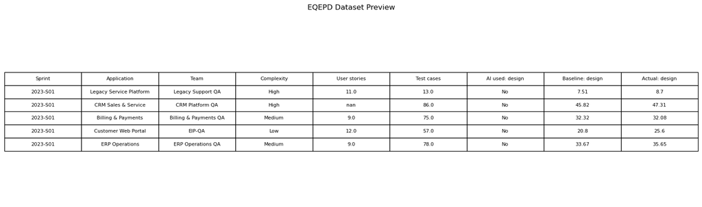

```
Saved: outputs\figures\Figure_03_EQEPD_Dataset_Preview.png
```

```python
preview_columns = [
    "Sprint #",
    "Application_Name",
    "Team_Name",
    "Complexity",
    "User story count",
    "test case count",
    "AI Usage Testing Phase (Test Design)",
    "Baseline effort (Test Design)",
    "Actual effort (Test Design)",
]
preview = data[preview_columns].head(5).copy()
preview.columns = [
    "Sprint", "Application", "Team", "Complexity", "User stories",
    "Test cases", "AI used: design", "Baseline: design", "Actual: design"
]

plt.figure(figsize=(16, 4.8))
axis = plt.gca()
axis.axis("off")
table = axis.table(
    cellText=preview.round(2).values,
    colLabels=preview.columns,
    loc="center",
    cellLoc="center",
)
table.auto_set_font_size(False)
table.set_fontsize(8)
table.scale(1, 1.6)
plt.title("EQEPD Dataset Preview", pad=18)
save_figure("Figure_03_EQEPD_Dataset_Preview.png")
```

## 2. Data Quality Assessment and Cleaning

```python
missing_summary = pd.DataFrame({
    "Variable": data.columns,
    "Missing_Count": data.isna().sum().values,
    "Missing_Percent": (data.isna().mean().values * 100),
}).sort_values(["Missing_Count", "Variable"], ascending=[False, True])

display(missing_summary[missing_summary["Missing_Count"] > 0])
missing_summary.to_csv(TABLES_DIR / "Missing_Value_Summary.csv", index=False)

duplicate_count = int(data.duplicated().sum())
print(f"Exact duplicate records identified: {duplicate_count}")
```

|  | Variable | Missing_Count | Missing_Percent |
| --- | --- | --- | --- |
| 10 | User story count | 6 | 1.307 |
| 20 | Actual effort (Automation Development) | 5 | 1.089 |
| 22 | Actual effort (Regression Testing) | 5 | 1.089 |
| 19 | Actual effort (Test Design) | 4 | 0.871 |
| 14 | Baseline effort (Automation Development) | 4 | 0.871 |
| 16 | Baseline effort (Regression Testing) | 3 | 0.654 |
| 15 | Baseline effort (Test Execution) | 3 | 0.654 |
| 12 | Baseline effort (Test Planning) | 3 | 0.654 |
| 11 | test case count | 3 | 0.654 |
| 23 | Actual effort (Defect Management) | 2 | 0.436 |
| 21 | Actual effort (Test Execution) | 2 | 0.436 |
| 18 | Actual effort (Test Planning) | 2 | 0.436 |
| 17 | Baseline effort (Defect Management) | 2 | 0.436 |
| 13 | Baseline effort (Test Design) | 2 | 0.436 |

```
Exact duplicate records identified: 2
```

### Figure 4. Missing Values by Variable

Contextual workload counts are median-imputed. Baseline and actual effort fields are not imputed for productivity calculations because imputation would manufacture the dependent outcome.

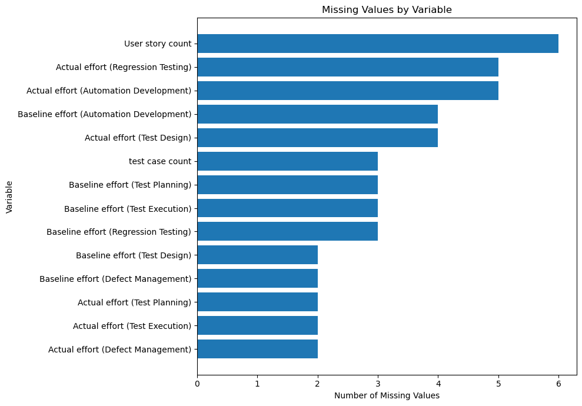

```
Saved: outputs\figures\Figure_04_Missing_Values_by_Variable.png
```

```python
missing_plot = (
    missing_summary[missing_summary["Missing_Count"] > 0]
    .sort_values("Missing_Count")
)

plt.figure(figsize=(10, 7))
plt.barh(missing_plot["Variable"], missing_plot["Missing_Count"])
plt.title("Missing Values by Variable")
plt.xlabel("Number of Missing Values")
plt.ylabel("Variable")
save_figure("Figure_04_Missing_Values_by_Variable.png")
```

```python
clean_data = data.drop_duplicates().copy()

application_map = {
    "legacy service platform": "Legacy Service Platform",
    "crm sales & service": "CRM Sales & Service",
    "billing & payments": "Billing & Payments",
    "customer web portal": "Customer Web Portal",
    "customer portal": "Customer Web Portal",
    "erp operations": "ERP Operations",
    "erp ops": "ERP Operations",
    "mobile service app": "Mobile Service App",
    "api integration platform": "API Integration Platform",
    "api platform": "API Integration Platform",
    "enterprise data platform": "Enterprise Data Platform",
}

team_map = {
    "legacy support qa": "Legacy Support QA",
    "crm platform qa": "CRM Platform QA",
    "crm qa": "CRM Platform QA",
    "billing & payments qa": "Billing & Payments QA",
    "billing-payments qa": "Billing & Payments QA",
    "billing qa": "Billing & Payments QA",
    "eip-qa": "EIP-QA",
    "erp operations qa": "ERP Operations QA",
    "mobile & web qe": "Mobile & Web QE",
    "mobile/web qe": "Mobile & Web QE",
    "api & middleware qa": "API & Middleware QA",
    "data platform qa": "Data Platform QA",
}

complexity_map = {
    "high": "High", "h": "High",
    "medium": "Medium", "med": "Medium",
    "low": "Low", "l": "Low",
}

clean_data["Application_Name"] = (
    clean_data["Application_Name"].astype(str).str.strip().str.casefold().map(application_map)
)
clean_data["Team_Name"] = (
    clean_data["Team_Name"].astype(str).str.strip().str.casefold().map(team_map)
)
clean_data["Complexity"] = (
    clean_data["Complexity"].astype(str).str.strip().str.casefold().map(complexity_map)
)

ai_columns = [
    column for column in clean_data.columns
    if column.startswith("AI Usage Testing Phase")
]

def normalise_ai_label(value):
    label = str(value).strip().casefold()
    if label in {"yes", "y"}:
        return "Yes"
    if label in {"no", "n"}:
        return "No"
    return np.nan

for column in ai_columns:
    clean_data[column] = clean_data[column].map(normalise_ai_label)

clean_data["Year"] = clean_data["Sprint #"].str.extract(r"(\d{4})").astype(int)
clean_data["Sprint_Number"] = clean_data["Sprint #"].str.extract(r"S(\d+)").astype(int)

context_imputation = {}
for column in ["User story count", "test case count"]:
    missing_before = int(clean_data[column].isna().sum())
    median_value = float(clean_data[column].median())
    clean_data[column] = clean_data[column].fillna(median_value)
    context_imputation[column] = (missing_before, median_value)

cleaning_log = pd.DataFrame([
    {
        "Issue": "Exact duplicate rows",
        "Variables_Affected": "All variables",
        "Detection_Method": "DataFrame duplicated check",
        "Treatment_Applied": f"Removed {duplicate_count} exact records",
        "Rationale": "Prevent duplicated observations from influencing summaries and models",
    },
    {
        "Issue": "Inconsistent categorical labels",
        "Variables_Affected": "Application, team, complexity, AI usage",
        "Detection_Method": "Unique-value inspection and case comparison",
        "Treatment_Applied": "Trimmed, case-normalised, and mapped to canonical labels",
        "Rationale": "Avoid artificial categories caused by spelling, case, or abbreviation differences",
    },
    {
        "Issue": "Missing contextual counts",
        "Variables_Affected": "User story count; test case count",
        "Detection_Method": "Missing-value profile",
        "Treatment_Applied": "Median imputation",
        "Rationale": "Retain observations without manufacturing effort outcomes",
    },
    {
        "Issue": "Missing baseline or actual effort",
        "Variables_Affected": "Phase effort fields",
        "Detection_Method": "Missing-value profile after reshaping",
        "Treatment_Applied": "Excluded only from the affected phase-level outcome calculation",
        "Rationale": "Imputing effort would manufacture the dependent variable",
    },
])
display(cleaning_log)
cleaning_log.to_csv(TABLES_DIR / "Data_Cleaning_Log.csv", index=False)

print(f"Rows before cleaning: {len(data):,}")
print(f"Rows after duplicate removal: {len(clean_data):,}")
print("Context imputation:", context_imputation)
```

|  | Issue | Variables_Affected | Detection_Method | Treatment_Applied | Rationale |
| --- | --- | --- | --- | --- | --- |
| 0 | Exact duplicate rows | All variables | DataFrame duplicated check | Removed 2 exact records | Prevent duplicated observations from influenci... |
| 1 | Inconsistent categorical labels | Application, team, complexity, AI usage | Unique-value inspection and case comparison | Trimmed, case-normalised, and mapped to canoni... | Avoid artificial categories caused by spelling... |
| 2 | Missing contextual counts | User story count; test case count | Missing-value profile | Median imputation | Retain observations without manufacturing effo... |
| 3 | Missing baseline or actual effort | Phase effort fields | Missing-value profile after reshaping | Excluded only from the affected phase-level ou... | Imputing effort would manufacture the dependen... |

```
Rows before cleaning: 459
Rows after duplicate removal: 457
Context imputation: {'User story count': (6, 10.0), 'test case count': (3, 66.0)}
```

## 3. Feature Engineering and Analytical Datasets

```python
phases = [
    "Test Planning",
    "Test Design",
    "Automation Development",
    "Test Execution",
    "Regression Testing",
    "Defect Management",
]

baseline_columns = [f"Baseline effort ({phase})" for phase in phases]
actual_columns = [f"Actual effort ({phase})" for phase in phases]

project_data = clean_data.copy()

for phase in phases:
    project_data[f"AI_{phase}"] = (
        project_data[f"AI Usage Testing Phase ({phase})"] == "Yes"
    ).astype(int)

project_data["AI_Phase_Count"] = project_data[
    [f"AI_{phase}" for phase in phases]
].sum(axis=1)
project_data["AI_Adoption_Rate"] = project_data["AI_Phase_Count"] / len(phases)

project_data["Total_Baseline_Effort"] = project_data[baseline_columns].sum(
    axis=1, min_count=len(phases)
)
project_data["Total_Actual_Effort"] = project_data[actual_columns].sum(
    axis=1, min_count=len(phases)
)
project_data["Total_Effort_Saved"] = (
    project_data["Total_Baseline_Effort"] - project_data["Total_Actual_Effort"]
)
project_data["Overall_Productivity_Improvement_Pct"] = (
    project_data["Total_Effort_Saved"]
    / project_data["Total_Baseline_Effort"]
    * 100
)
project_data["Story_to_Test_Ratio"] = (
    project_data["test case count"] / (project_data["User story count"] + 1)
)

phase_records = []
for row_id, row in project_data.iterrows():
    for phase in phases:
        phase_records.append({
            "Row_ID": row_id,
            "Sprint #": row["Sprint #"],
            "Year": row["Year"],
            "Sprint_Number": row["Sprint_Number"],
            "Application_Name": row["Application_Name"],
            "Team_Name": row["Team_Name"],
            "Complexity": row["Complexity"],
            "User story count": row["User story count"],
            "test case count": row["test case count"],
            "QE_Phase": phase,
            "AI_Used": row[f"AI Usage Testing Phase ({phase})"],
            "Baseline_Effort": row[f"Baseline effort ({phase})"],
            "Actual_Effort": row[f"Actual effort ({phase})"],
        })

phase_data = pd.DataFrame(phase_records)
phase_data["AI_Used_Flag"] = (phase_data["AI_Used"] == "Yes").astype(int)
phase_data["Effort_Saved"] = (
    phase_data["Baseline_Effort"] - phase_data["Actual_Effort"]
)
phase_data["Productivity_Improvement_Pct"] = np.where(
    phase_data["Baseline_Effort"] > 0,
    phase_data["Effort_Saved"] / phase_data["Baseline_Effort"] * 100,
    np.nan,
)
phase_data["Actual_to_Baseline_Ratio"] = np.where(
    phase_data["Baseline_Effort"] > 0,
    phase_data["Actual_Effort"] / phase_data["Baseline_Effort"],
    np.nan,
)
phase_data["Story_to_Test_Ratio"] = (
    phase_data["test case count"] / (phase_data["User story count"] + 1)
)
phase_data["Baseline_Effort_per_Story"] = (
    phase_data["Baseline_Effort"] / (phase_data["User story count"] + 1)
)

phase_valid = phase_data.dropna(
    subset=["Baseline_Effort", "Actual_Effort", "Productivity_Improvement_Pct"]
).copy()

analysis_inventory = pd.DataFrame({
    "Measure": [
        "Clean project/sprint observations",
        "Potential phase observations",
        "Valid phase productivity observations",
        "AI-assisted valid phase observations",
        "Traditional valid phase observations",
        "Applications after standardisation",
        "Teams after standardisation",
    ],
    "Value": [
        len(project_data),
        len(phase_data),
        len(phase_valid),
        int((phase_valid["AI_Used"] == "Yes").sum()),
        int((phase_valid["AI_Used"] == "No").sum()),
        project_data["Application_Name"].nunique(),
        project_data["Team_Name"].nunique(),
    ],
})
display(analysis_inventory)
analysis_inventory.to_csv(TABLES_DIR / "Analytical_Dataset_Inventory.csv", index=False)

project_data.to_csv(
    PROCESSED_DIR / "EQEPD_Cleaned_Project_Level.csv", index=False
)
phase_data.to_csv(
    PROCESSED_DIR / "EQEPD_Engineered_Phase_Level.csv", index=False
)
```

|  | Measure | Value |
| --- | --- | --- |
| 0 | Clean project/sprint observations | 457 |
| 1 | Potential phase observations | 2742 |
| 2 | Valid phase productivity observations | 2705 |
| 3 | AI-assisted valid phase observations | 906 |
| 4 | Traditional valid phase observations | 1799 |
| 5 | Applications after standardisation | 8 |
| 6 | Teams after standardisation | 8 |

## 4. Exploratory Data Analysis

```python
numeric_summary = phase_valid[
    [
        "Baseline_Effort",
        "Actual_Effort",
        "Effort_Saved",
        "Productivity_Improvement_Pct",
    ]
].describe(percentiles=[0.01, 0.05, 0.25, 0.50, 0.75, 0.95, 0.99]).T

display(numeric_summary)
numeric_summary.to_csv(TABLES_DIR / "Phase_Level_Numeric_Summary.csv")
```

|  | count | mean | std | min | 1% | 5% | 25% | 50% | 75% | 95% | 99% | max |
| --- | --- | --- | --- | --- | --- | --- | --- | --- | --- | --- | --- | --- |
| Baseline_Effort | 2,705.000 | 21.035 | 12.893 | 2.500 | 5.000 | 7.150 | 11.320 | 17.300 | 27.820 | 46.701 | 62.821 | 98.280 |
| Actual_Effort | 2,705.000 | 19.840 | 12.223 | 0.000 | 4.800 | 7.000 | 11.300 | 16.570 | 25.280 | 42.876 | 61.256 | 111.800 |
| Effort_Saved | 2,705.000 | 1.195 | 5.345 | -41.000 | -13.325 | -5.300 | -1.080 | 0.247 | 2.990 | 10.764 | 17.070 | 28.840 |
| Productivity_Improvement_Pct | 2,705.000 | 2.600 | 21.220 | -133.787 | -85.165 | -23.076 | -7.533 | 1.667 | 14.778 | 33.914 | 42.987 | 100.000 |

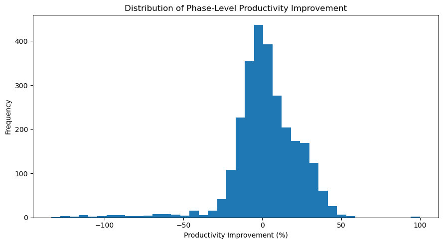

```
Saved: outputs\figures\Appendix_Figure_A1_Productivity_Distribution.png
```

```python
plt.figure(figsize=(9, 5))
plt.hist(phase_valid["Productivity_Improvement_Pct"], bins=40)
plt.title("Distribution of Phase-Level Productivity Improvement")
plt.xlabel("Productivity Improvement (%)")
plt.ylabel("Frequency")
save_figure("Appendix_Figure_A1_Productivity_Distribution.png")
```

### Figure 5. AI Adoption Rate Across Years

The annual percentage is calculated over phase observations. It shows the gradual expansion of AI use, not the proportion of entire projects that use AI.

| Year | AI Adoption Rate (%) |
| --- | --- |
| 2023 | 7.165 |
| 2024 | 20.655 |
| 2025 | 42.667 |
| 2026 | 64.198 |

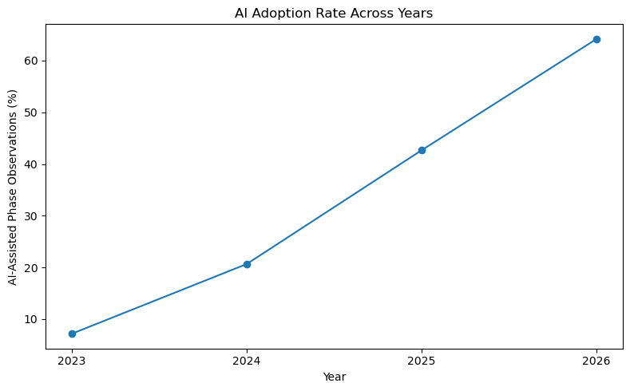

```
Saved: outputs\figures\Figure_05_AI_Adoption_Rate_Across_Years.png
```

```python
adoption_by_year = (
    phase_data.groupby("Year")["AI_Used_Flag"].mean() * 100
)
display(adoption_by_year.rename("AI Adoption Rate (%)").to_frame())
adoption_by_year.rename("AI Adoption Rate (%)").to_csv(
    TABLES_DIR / "AI_Adoption_by_Year.csv"
)

plt.figure(figsize=(8, 5))
plt.plot(adoption_by_year.index, adoption_by_year.values, marker="o")
plt.title("AI Adoption Rate Across Years")
plt.xlabel("Year")
plt.ylabel("AI-Assisted Phase Observations (%)")
plt.xticks(adoption_by_year.index)
save_figure("Figure_05_AI_Adoption_Rate_Across_Years.png")
```

### Figure 6. AI Adoption Rate by QE Lifecycle Phase

Phase-level adoption identifies where AI capability is most frequently used. Adoption frequency should not be interpreted as proof of benefit; it is considered together with productivity outcomes.

| QE_Phase | AI Adoption Rate (%) |
| --- | --- |
| Test Design | 66.083 |
| Automation Development | 54.267 |
| Regression Testing | 38.293 |
| Defect Management | 24.945 |
| Test Planning | 13.129 |
| Test Execution | 6.127 |

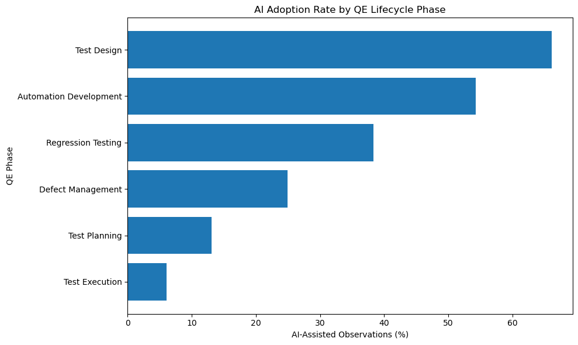

```
Saved: outputs\figures\Figure_06_AI_Adoption_Rate_by_QE_Phase.png
```

```python
adoption_by_phase = (
    phase_data.groupby("QE_Phase")["AI_Used_Flag"].mean() * 100
).sort_values(ascending=False)

display(adoption_by_phase.rename("AI Adoption Rate (%)").to_frame())
adoption_by_phase.rename("AI Adoption Rate (%)").to_csv(
    TABLES_DIR / "AI_Adoption_by_Phase.csv"
)

plt.figure(figsize=(10, 6))
plt.barh(adoption_by_phase.index, adoption_by_phase.values)
plt.gca().invert_yaxis()
plt.title("AI Adoption Rate by QE Lifecycle Phase")
plt.xlabel("AI-Assisted Observations (%)")
plt.ylabel("QE Phase")
save_figure("Figure_06_AI_Adoption_Rate_by_QE_Phase.png")
```

```python
ai_productivity_summary = phase_valid.groupby("AI_Used").agg(
    Observations=("Productivity_Improvement_Pct", "count"),
    Mean_Productivity_Improvement_Pct=("Productivity_Improvement_Pct", "mean"),
    Median_Productivity_Improvement_Pct=("Productivity_Improvement_Pct", "median"),
    Mean_Effort_Saved=("Effort_Saved", "mean"),
    Median_Effort_Saved=("Effort_Saved", "median"),
)
display(ai_productivity_summary)
ai_productivity_summary.to_csv(
    TABLES_DIR / "AI_vs_Traditional_Productivity_Summary.csv"
)
```

| AI_Used | Observations | Mean_Productivity_Improvement_Pct | Median_Productivity_Improvement_Pct | Mean_Effort_Saved | Median_Effort_Saved |
| --- | --- | --- | --- | --- | --- |
| No | 1799 | -4.629 | -2.714 | -0.658 | -0.340 |
| Yes | 906 | 16.953 | 20.264 | 4.876 | 4.800 |

### Figure 7. Productivity Improvement for AI-Assisted and Traditional Activities

Extreme points are suppressed only in the display so that the distributions remain legible. Every valid observation remains in the descriptive and inferential calculations.

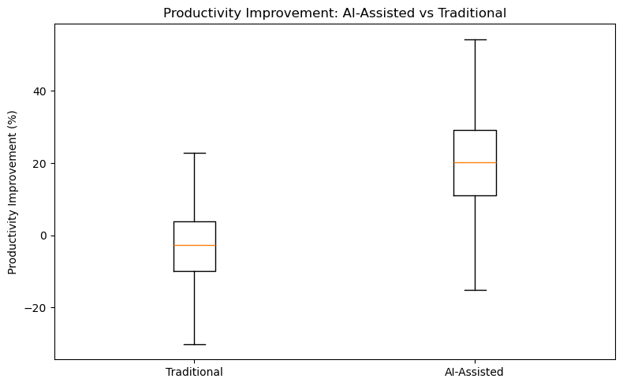

```
Saved: outputs\figures\Figure_07_AI_Assisted_vs_Traditional_Productivity.png
```

```python
ai_values = phase_valid.loc[
    phase_valid["AI_Used"] == "Yes", "Productivity_Improvement_Pct"
]
traditional_values = phase_valid.loc[
    phase_valid["AI_Used"] == "No", "Productivity_Improvement_Pct"
]

plt.figure(figsize=(8, 5))
plt.boxplot(
    [traditional_values, ai_values],
    labels=["Traditional", "AI-Assisted"],
    showfliers=False,
)
plt.title("Productivity Improvement: AI-Assisted vs Traditional")
plt.ylabel("Productivity Improvement (%)")
save_figure("Figure_07_AI_Assisted_vs_Traditional_Productivity.png")
```

```python
ai_phase_summary = (
    phase_valid[phase_valid["AI_Used"] == "Yes"]
    .groupby("QE_Phase")
    .agg(
        AI_Activities=("Productivity_Improvement_Pct", "count"),
        Mean_Productivity_Improvement_Pct=(
            "Productivity_Improvement_Pct", "mean"
        ),
        Median_Productivity_Improvement_Pct=(
            "Productivity_Improvement_Pct", "median"
        ),
        Mean_Effort_Saved=("Effort_Saved", "mean"),
        Total_Effort_Saved=("Effort_Saved", "sum"),
    )
    .sort_values("Mean_Productivity_Improvement_Pct", ascending=False)
)
display(ai_phase_summary)
ai_phase_summary.to_csv(TABLES_DIR / "AI_Productivity_by_Phase.csv")
```

| QE_Phase | AI_Activities | Mean_Productivity_Improvement_Pct | Median_Productivity_Improvement_Pct | Mean_Effort_Saved | Total_Effort_Saved |
| --- | --- | --- | --- | --- | --- |
| Regression Testing | 171 | 22.228 | 24.148 | 5.243 | 896.606 |
| Test Design | 297 | 19.917 | 23.240 | 6.254 | 1,857.580 |
| Automation Development | 242 | 16.624 | 19.685 | 5.869 | 1,420.183 |
| Defect Management | 111 | 10.272 | 15.920 | 1.661 | 184.392 |
| Test Planning | 58 | 6.456 | 10.245 | 0.796 | 46.155 |
| Test Execution | 27 | 3.926 | 9.091 | 0.471 | 12.714 |

### Figure 8. Mean Productivity Improvement for AI-Assisted Activities by Phase

The chart directly supports RQ2. Regression Testing has the highest mean improvement, followed by Test Design and Automation Development.

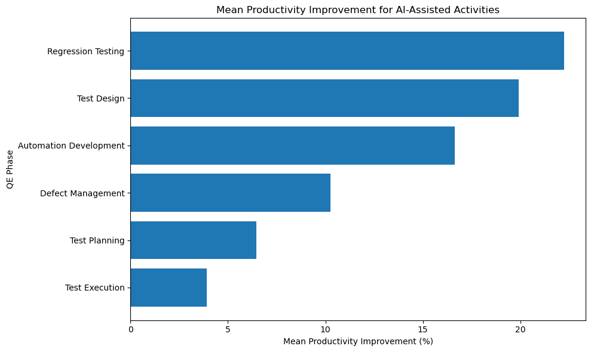

```
Saved: outputs\figures\Figure_08_AI_Assisted_Productivity_by_Phase.png
```

```python
plt.figure(figsize=(10, 6))
plt.barh(
    ai_phase_summary.index,
    ai_phase_summary["Mean_Productivity_Improvement_Pct"],
)
plt.gca().invert_yaxis()
plt.title("Mean Productivity Improvement for AI-Assisted Activities")
plt.xlabel("Mean Productivity Improvement (%)")
plt.ylabel("QE Phase")
save_figure("Figure_08_AI_Assisted_Productivity_by_Phase.png")
```

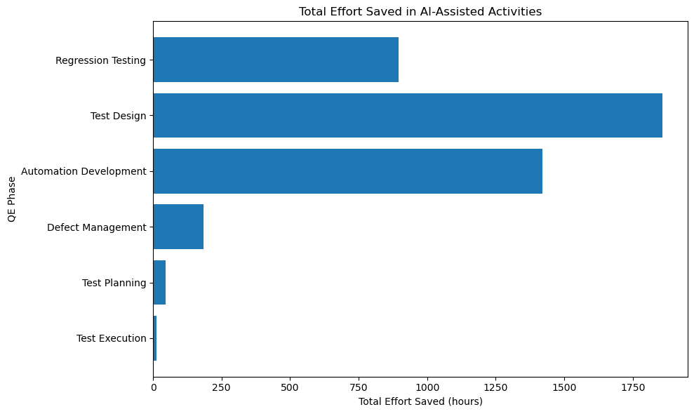

```
Saved: outputs\figures\Appendix_Figure_A6_Total_Effort_Saved_by_Phase.png
```

```python
plt.figure(figsize=(10, 6))
plt.barh(
    ai_phase_summary.index,
    ai_phase_summary["Total_Effort_Saved"],
)
plt.gca().invert_yaxis()
plt.title("Total Effort Saved in AI-Assisted Activities")
plt.xlabel("Total Effort Saved (hours)")
plt.ylabel("QE Phase")
save_figure("Appendix_Figure_A6_Total_Effort_Saved_by_Phase.png")
```

### Figure 9. Relationship Between AI Adoption Breadth and Overall Productivity

The relationship is descriptive. The six-phase category contains few records and therefore has greater uncertainty.

| AI_Phase_Count | Records | Mean_Overall_Productivity | Median_Overall_Productivity |
| --- | --- | --- | --- |
| 0 | 119 | -4.624 | -4.189 |
| 1 | 63 | 0.981 | 0.962 |
| 2 | 78 | 6.887 | 7.326 |
| 3 | 71 | 9.729 | 10.017 |
| 4 | 45 | 12.965 | 13.599 |
| 5 | 38 | 16.925 | 20.586 |
| 6 | 7 | 18.474 | 21.824 |

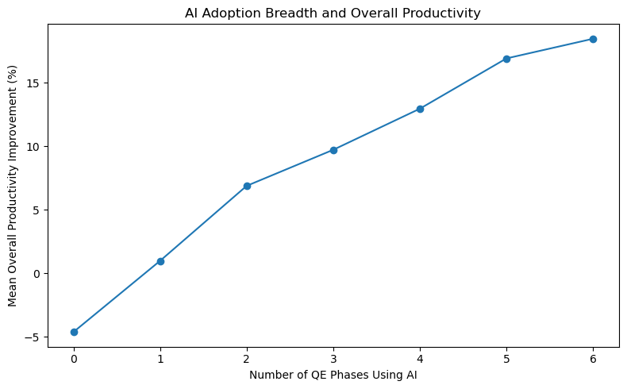

```
Saved: outputs\figures\Figure_09_AI_Adoption_Breadth_vs_Overall_Productivity.png
```

```python
ai_breadth_summary = (
    project_data.dropna(subset=["Overall_Productivity_Improvement_Pct"])
    .groupby("AI_Phase_Count")
    .agg(
        Records=("Overall_Productivity_Improvement_Pct", "count"),
        Mean_Overall_Productivity=(
            "Overall_Productivity_Improvement_Pct", "mean"
        ),
        Median_Overall_Productivity=(
            "Overall_Productivity_Improvement_Pct", "median"
        ),
    )
)
display(ai_breadth_summary)
ai_breadth_summary.to_csv(TABLES_DIR / "AI_Breadth_Productivity_Summary.csv")

plt.figure(figsize=(8, 5))
plt.plot(
    ai_breadth_summary.index,
    ai_breadth_summary["Mean_Overall_Productivity"],
    marker="o",
)
plt.title("AI Adoption Breadth and Overall Productivity")
plt.xlabel("Number of QE Phases Using AI")
plt.ylabel("Mean Overall Productivity Improvement (%)")
plt.xticks(ai_breadth_summary.index)
save_figure("Figure_09_AI_Adoption_Breadth_vs_Overall_Productivity.png")
```

|  | AI_Used_Flag | Year | Sprint_Number | User story count | test case count | Baseline_Effort | Actual_Effort | Effort_Saved | Productivity_Improvement_Pct |
| --- | --- | --- | --- | --- | --- | --- | --- | --- | --- |
| AI_Used_Flag | 1.000 | 0.445 | 0.114 | 0.100 | 0.114 | 0.391 | 0.210 | 0.575 | 0.579 |
| Year | 0.445 | 1.000 | 0.007 | 0.101 | 0.180 | 0.102 | 0.013 | 0.267 | 0.270 |
| Sprint_Number | 0.114 | 0.007 | 1.000 | 0.081 | -0.065 | -0.046 | -0.070 | 0.071 | 0.072 |
| User story count | 0.100 | 0.101 | 0.081 | 1.000 | 0.090 | 0.130 | 0.109 | 0.070 | 0.069 |
| test case count | 0.114 | 0.180 | -0.065 | 0.090 | 1.000 | 0.456 | 0.442 | 0.120 | 0.097 |
| Baseline_Effort | 0.391 | 0.102 | -0.046 | 0.130 | 0.456 | 1.000 | 0.934 | 0.296 | 0.284 |
| Actual_Effort | 0.210 | 0.013 | -0.070 | 0.109 | 0.442 | 0.934 | 1.000 | -0.002 | -0.030 |
| Effort_Saved | 0.575 | 0.267 | 0.071 | 0.070 | 0.120 | 0.296 | -0.002 | 1.000 | 0.972 |
| Productivity_Improvement_Pct | 0.579 | 0.270 | 0.072 | 0.069 | 0.097 | 0.284 | -0.030 | 0.972 | 1.000 |

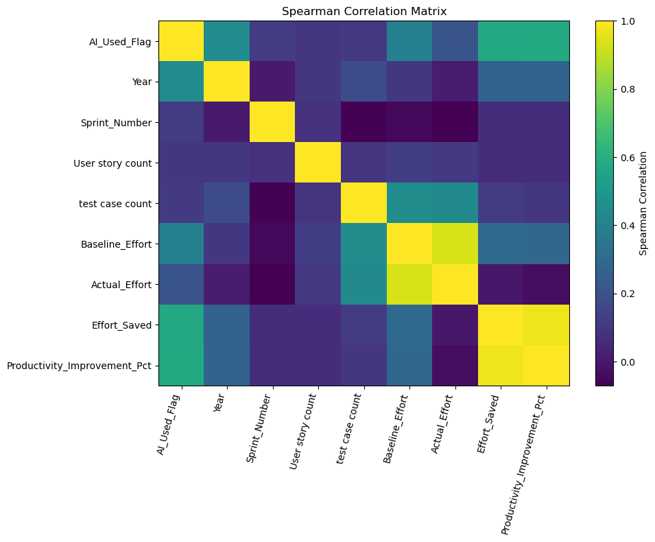

```
Saved: outputs\figures\Appendix_Figure_A2_Spearman_Correlation_Matrix.png
```

```python
correlation_columns = [
    "AI_Used_Flag",
    "Year",
    "Sprint_Number",
    "User story count",
    "test case count",
    "Baseline_Effort",
    "Actual_Effort",
    "Effort_Saved",
    "Productivity_Improvement_Pct",
]
correlation_matrix = phase_valid[correlation_columns].corr(method="spearman")
display(correlation_matrix)
correlation_matrix.to_csv(TABLES_DIR / "Spearman_Correlation_Matrix.csv")

plt.figure(figsize=(10, 8))
plt.imshow(correlation_matrix, aspect="auto")
plt.colorbar(label="Spearman Correlation")
plt.xticks(
    range(len(correlation_columns)),
    correlation_columns,
    rotation=75,
    ha="right",
)
plt.yticks(range(len(correlation_columns)), correlation_columns)
plt.title("Spearman Correlation Matrix")
save_figure("Appendix_Figure_A2_Spearman_Correlation_Matrix.png")
```

## 5. Preliminary Statistical Results

### RQ1: AI-Assisted Versus Traditional Productivity

Because the distributions are non-normal and group variances differ, the Mann-Whitney U test is used as the primary inferential test. Welch's t-test is retained as a robustness comparison. Cohen's *d* and rank-biserial correlation provide practical-effect measures.

```python
levene_result = stats.levene(ai_values, traditional_values, center="median")
welch_result = stats.ttest_ind(
    ai_values, traditional_values, equal_var=False
)
mann_whitney_result = stats.mannwhitneyu(
    ai_values, traditional_values, alternative="two-sided"
)

def cohens_d(group_1, group_2):
    n1, n2 = len(group_1), len(group_2)
    variance_1 = group_1.var(ddof=1)
    variance_2 = group_2.var(ddof=1)
    pooled_sd = math.sqrt(
        ((n1 - 1) * variance_1 + (n2 - 1) * variance_2)
        / (n1 + n2 - 2)
    )
    return (group_1.mean() - group_2.mean()) / pooled_sd

cohen_d = cohens_d(ai_values, traditional_values)
rank_biserial = (
    2 * mann_whitney_result.statistic
    / (len(ai_values) * len(traditional_values))
    - 1
)

rq1_results = pd.DataFrame({
    "Measure": [
        "AI mean productivity improvement (%)",
        "Traditional mean productivity improvement (%)",
        "Difference in means (percentage points)",
        "Levene p-value",
        "Welch t-test statistic",
        "Welch t-test p-value",
        "Mann-Whitney U statistic",
        "Mann-Whitney p-value",
        "Cohen's d",
        "Rank-biserial correlation",
    ],
    "Result": [
        ai_values.mean(),
        traditional_values.mean(),
        ai_values.mean() - traditional_values.mean(),
        levene_result.pvalue,
        welch_result.statistic,
        welch_result.pvalue,
        mann_whitney_result.statistic,
        mann_whitney_result.pvalue,
        cohen_d,
        rank_biserial,
    ],
})
display(rq1_results)
rq1_results.to_csv(TABLES_DIR / "RQ1_Preliminary_Results.csv", index=False)
```

|  | Measure | Result |
| --- | --- | --- |
| 0 | AI mean productivity improvement (%) | 16.953 |
| 1 | Traditional mean productivity improvement (%) | -4.629 |
| 2 | Difference in means (percentage points) | 21.582 |
| 3 | Levene p-value | 0.000 |
| 4 | Welch t-test statistic | 27.481 |
| 5 | Welch t-test p-value | 0.000 |
| 6 | Mann-Whitney U statistic | 1,392,443.000 |
| 7 | Mann-Whitney p-value | 0.000 |
| 8 | Cohen's d | 1.159 |
| 9 | Rank-biserial correlation | 0.709 |

### RQ2: Differences Across QE Lifecycle Phases

The Kruskal-Wallis test assesses whether the distribution of productivity improvement differs across the six AI-assisted phase groups. Pairwise Mann-Whitney tests use Holm adjustment to control family-wise error.

```python
ai_only = phase_valid[phase_valid["AI_Used"] == "Yes"].copy()

phase_groups = [
    ai_only.loc[
        ai_only["QE_Phase"] == phase,
        "Productivity_Improvement_Pct",
    ].values
    for phase in phases
]

kruskal_result = stats.kruskal(*phase_groups)
epsilon_squared = (
    kruskal_result.statistic - len(phases) + 1
) / (len(ai_only) - len(phases))

rq2_overall = pd.DataFrame({
    "Test": ["Kruskal-Wallis H", "p-value", "Epsilon-squared"],
    "Result": [
        kruskal_result.statistic,
        kruskal_result.pvalue,
        epsilon_squared,
    ],
})
display(rq2_overall)
rq2_overall.to_csv(TABLES_DIR / "RQ2_Overall_Test.csv", index=False)

pairwise_results = []
for phase_a, phase_b in combinations(phases, 2):
    values_a = ai_only.loc[
        ai_only["QE_Phase"] == phase_a,
        "Productivity_Improvement_Pct",
    ]
    values_b = ai_only.loc[
        ai_only["QE_Phase"] == phase_b,
        "Productivity_Improvement_Pct",
    ]
    test_result = stats.mannwhitneyu(
        values_a, values_b, alternative="two-sided"
    )
    effect_size = (
        2 * test_result.statistic / (len(values_a) * len(values_b)) - 1
    )
    pairwise_results.append({
        "Phase_A": phase_a,
        "Phase_B": phase_b,
        "Raw_p_value": test_result.pvalue,
        "Rank_Biserial": effect_size,
    })

pairwise_results = pd.DataFrame(pairwise_results)
pairwise_results["Holm_Adjusted_p"] = multipletests(
    pairwise_results["Raw_p_value"], method="holm"
)[1]
pairwise_results["Significant_at_0.05"] = (
    pairwise_results["Holm_Adjusted_p"] < 0.05
)

pairwise_results = pairwise_results.sort_values(
    "Holm_Adjusted_p"
).reset_index(drop=True)
display(pairwise_results)
pairwise_results.to_csv(
    TABLES_DIR / "RQ2_Phase_PostHoc_Results.csv", index=False
)
```

|  | Test | Result |
| --- | --- | --- |
| 0 | Kruskal-Wallis H | 92.721 |
| 1 | p-value | 0.000 |
| 2 | Epsilon-squared | 0.097 |

|  | Phase_A | Phase_B | Raw_p_value | Rank_Biserial | Holm_Adjusted_p | Significant_at_0.05 |
| --- | --- | --- | --- | --- | --- | --- |
| 0 | Test Planning | Regression Testing | 0.000 | -0.568 | 0.000 | True |
| 1 | Test Planning | Test Design | 0.000 | -0.524 | 0.000 | True |
| 2 | Test Execution | Regression Testing | 0.000 | -0.660 | 0.000 | True |
| 3 | Test Design | Test Execution | 0.000 | 0.609 | 0.000 | True |
| 4 | Regression Testing | Defect Management | 0.000 | 0.369 | 0.000 | True |
| 5 | Test Planning | Automation Development | 0.000 | -0.416 | 0.000 | True |
| 6 | Test Design | Defect Management | 0.000 | 0.312 | 0.000 | True |
| 7 | Automation Development | Test Execution | 0.000 | 0.521 | 0.000 | True |
| 8 | Automation Development | Regression Testing | 0.000 | -0.210 | 0.002 | True |
| 9 | Test Design | Automation Development | 0.003 | 0.149 | 0.018 | True |
| 10 | Automation Development | Defect Management | 0.007 | 0.179 | 0.035 | True |
| 11 | Test Execution | Defect Management | 0.008 | -0.332 | 0.035 | True |
| 12 | Test Planning | Defect Management | 0.015 | -0.228 | 0.046 | True |
| 13 | Test Planning | Test Execution | 0.348 | 0.128 | 0.515 | False |
| 14 | Test Design | Regression Testing | 0.257 | -0.063 | 0.515 | False |

### RQ3: Preliminary Influence Model

A multiple linear regression is estimated on the phase-level dataset. The target is winsorised at the 1st and 99th percentiles to reduce extreme leverage, and standard errors are clustered by sprint. Coefficients remain associations rather than causal effects.

```python
regression_data = phase_valid.copy()
lower_clip, upper_clip = regression_data[
    "Productivity_Improvement_Pct"
].quantile([0.01, 0.99])

regression_data["Productivity_Winsorized"] = regression_data[
    "Productivity_Improvement_Pct"
].clip(lower_clip, upper_clip)

regression_data = regression_data.rename(columns={
    "Productivity_Winsorized": "Productivity",
    "AI_Used_Flag": "AI_Flag",
    "Baseline_Effort": "Baseline",
    "User story count": "User_Stories",
    "test case count": "Test_Cases",
    "QE_Phase": "Phase",
    "Application_Name": "Application",
})

regression_formula = (
    "Productivity ~ AI_Flag + Baseline + User_Stories + Test_Cases "
    "+ Year + Sprint_Number + C(Phase) + C(Complexity) + C(Application)"
)

influence_model = smf.ols(
    regression_formula, data=regression_data
).fit(
    cov_type="cluster",
    cov_kwds={"groups": regression_data["Sprint #"]},
)

coefficient_table = pd.DataFrame({
    "Coefficient": influence_model.params,
    "p_value": influence_model.pvalues,
    "t_value": influence_model.tvalues,
    "CI_Lower": influence_model.conf_int()[0],
    "CI_Upper": influence_model.conf_int()[1],
})
coefficient_table["Absolute_t"] = coefficient_table["t_value"].abs()
coefficient_table = coefficient_table.sort_values(
    "Absolute_t", ascending=False
)

display(coefficient_table.head(15))
coefficient_table.to_csv(TABLES_DIR / "RQ3_Regression_Coefficients.csv")
(TABLES_DIR / "RQ3_Regression_Summary.txt").write_text(
    influence_model.summary().as_text(),
    encoding="utf-8",
)
```

|  | Coefficient | p_value | t_value | CI_Lower | CI_Upper | Absolute_t |
| --- | --- | --- | --- | --- | --- | --- |
| AI_Flag | 16.686 | 0.000 | 13.409 | 14.247 | 19.125 | 13.409 |
| C(Phase)[T.Test Execution] | -6.223 | 0.001 | -3.189 | -10.049 | -2.398 | 3.189 |
| C(Phase)[T.Defect Management] | -4.673 | 0.002 | -3.139 | -7.592 | -1.755 | 3.139 |
| C(Phase)[T.Test Planning] | -6.144 | 0.002 | -3.136 | -9.984 | -2.304 | 3.136 |
| Test_Cases | 0.050 | 0.006 | 2.736 | 0.014 | 0.086 | 2.736 |
| C(Phase)[T.Test Design] | 3.077 | 0.009 | 2.607 | 0.763 | 5.391 | 2.607 |
| C(Application)[T.Customer Web Portal] | 2.563 | 0.039 | 2.068 | 0.133 | 4.992 | 2.068 |
| Intercept | -1,699.977 | 0.053 | -1.933 | -3,423.978 | 24.024 | 1.933 |
| Year | 0.838 | 0.054 | 1.927 | -0.014 | 1.690 | 1.927 |
| Baseline | -0.075 | 0.168 | -1.379 | -0.182 | 0.032 | 1.379 |
| User_Stories | 0.110 | 0.214 | 1.242 | -0.064 | 0.284 | 1.242 |
| C(Complexity)[T.Low] | -0.903 | 0.325 | -0.984 | -2.701 | 0.895 | 0.984 |
| C(Application)[T.Enterprise Data Platform] | -1.324 | 0.340 | -0.955 | -4.042 | 1.394 | 0.955 |
| C(Application)[T.Mobile Service App] | 1.168 | 0.343 | 0.949 | -1.245 | 3.580 | 0.949 |
| C(Application)[T.CRM Sales & Service] | 1.067 | 0.356 | 0.923 | -1.198 | 3.332 | 0.923 |

```
4212
```

## 6. Preliminary Predictive Modelling

```python
model_data = project_data.dropna(
    subset=["Overall_Productivity_Improvement_Pct"]
).copy()

target_lower, target_upper = model_data[
    "Overall_Productivity_Improvement_Pct"
].quantile([0.01, 0.99])
model_data["Target_Productivity"] = model_data[
    "Overall_Productivity_Improvement_Pct"
].clip(target_lower, target_upper)

for phase in phases:
    baseline_column = f"Baseline effort ({phase})"
    model_data[f"Baseline_Share_{phase}"] = (
        model_data[baseline_column] / model_data["Total_Baseline_Effort"]
    )
    model_data[f"AI_Exposure_{phase}"] = (
        model_data[f"AI_{phase}"]
        * model_data[f"Baseline_Share_{phase}"]
    )

feature_columns = [
    "Application_Name",
    "Complexity",
    "Year",
    "Sprint_Number",
    "User story count",
    "test case count",
    "Story_to_Test_Ratio",
    "AI_Phase_Count",
    "Total_Baseline_Effort",
] + baseline_columns + [
    f"AI_{phase}" for phase in phases
] + [
    f"Baseline_Share_{phase}" for phase in phases
] + [
    f"AI_Exposure_{phase}" for phase in phases
]

X = model_data[feature_columns]
y = model_data["Target_Productivity"]
groups = model_data["Sprint #"]

group_split = GroupShuffleSplit(
    n_splits=1, test_size=0.20, random_state=42
)
train_index, test_index = next(
    group_split.split(X, y, groups=groups)
)

X_train = X.iloc[train_index]
X_test = X.iloc[test_index]
y_train = y.iloc[train_index]
y_test = y.iloc[test_index]

categorical_features = [
    column for column in feature_columns
    if X[column].dtype == "object"
]
numerical_features = [
    column for column in feature_columns
    if column not in categorical_features
]

split_summary = pd.DataFrame({
    "Measure": [
        "Modelling records",
        "Training records",
        "Testing records",
        "Training sprints",
        "Testing sprints",
        "Sprint overlap",
    ],
    "Value": [
        len(model_data),
        len(X_train),
        len(X_test),
        groups.iloc[train_index].nunique(),
        groups.iloc[test_index].nunique(),
        len(
            set(groups.iloc[train_index].unique()).intersection(
                set(groups.iloc[test_index].unique())
            )
        ),
    ],
})
display(split_summary)
split_summary.to_csv(TABLES_DIR / "Model_Split_Summary.csv", index=False)
```

|  | Measure | Value |
| --- | --- | --- |
| 0 | Modelling records | 421 |
| 1 | Training records | 338 |
| 2 | Testing records | 83 |
| 3 | Training sprints | 64 |
| 4 | Testing sprints | 16 |
| 5 | Sprint overlap | 0 |

```python
preprocessor = ColumnTransformer(
    transformers=[
        (
            "numeric",
            Pipeline(steps=[
                ("imputer", SimpleImputer(strategy="median")),
                ("scaler", StandardScaler()),
            ]),
            numerical_features,
        ),
        (
            "categorical",
            Pipeline(steps=[
                ("imputer", SimpleImputer(strategy="most_frequent")),
                ("encoder", OneHotEncoder(handle_unknown="ignore")),
            ]),
            categorical_features,
        ),
    ]
)

models = {
    "Linear Regression": LinearRegression(),
    "Random Forest": RandomForestRegressor(
        n_estimators=400,
        max_depth=10,
        min_samples_leaf=2,
        max_features=0.8,
        random_state=42,
        n_jobs=1,
    ),
    "Gradient Boosting": GradientBoostingRegressor(
        n_estimators=350,
        learning_rate=0.03,
        max_depth=2,
        min_samples_leaf=3,
        subsample=0.9,
        random_state=42,
    ),
}

model_results = []
fitted_models = {}
test_predictions = {}

for model_name, estimator in models.items():
    pipeline = Pipeline(steps=[
        ("preprocessor", preprocessor),
        ("model", estimator),
    ])
    pipeline.fit(X_train, y_train)
    predictions = pipeline.predict(X_test)

    model_results.append({
        "Model": model_name,
        "MAE": mean_absolute_error(y_test, predictions),
        "RMSE": math.sqrt(mean_squared_error(y_test, predictions)),
        "R2": r2_score(y_test, predictions),
    })
    fitted_models[model_name] = pipeline
    test_predictions[model_name] = predictions

model_results = (
    pd.DataFrame(model_results)
    .sort_values("R2", ascending=False)
    .reset_index(drop=True)
)
display(model_results)
model_results.to_csv(TABLES_DIR / "Preliminary_Model_Comparison.csv", index=False)
```

|  | Model | MAE | RMSE | R2 |
| --- | --- | --- | --- | --- |
| 0 | Random Forest | 5.685 | 7.286 | 0.405 |
| 1 | Linear Regression | 5.802 | 7.460 | 0.376 |
| 2 | Gradient Boosting | 5.935 | 7.512 | 0.368 |

### Figure 10. Grouped Holdout Model Comparison

The split is grouped by sprint to prevent observations from the same sprint appearing in both training and test sets. Random Forest provides the strongest preliminary holdout performance, although its R² remains moderate.

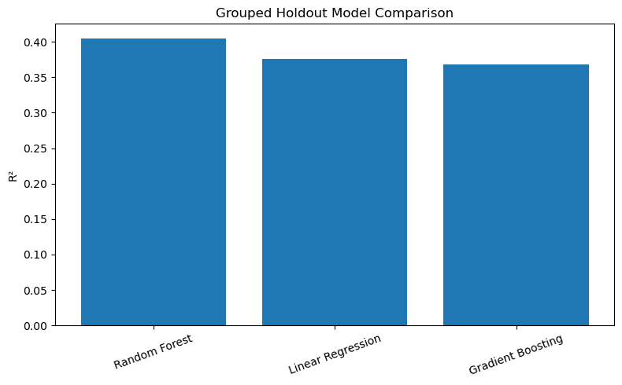

```
Saved: outputs\figures\Figure_10_Grouped_Holdout_Model_Comparison.png
```

```python
plt.figure(figsize=(8, 5))
plt.bar(model_results["Model"], model_results["R2"])
plt.title("Grouped Holdout Model Comparison")
plt.ylabel("R²")
plt.xticks(rotation=20)
save_figure("Figure_10_Grouped_Holdout_Model_Comparison.png")
```

```python
cross_validation = GroupKFold(n_splits=5)
cv_results = []

for model_name, pipeline in fitted_models.items():
    scores = cross_validate(
        pipeline,
        X,
        y,
        groups=groups,
        cv=cross_validation,
        scoring={
            "mae": "neg_mean_absolute_error",
            "rmse": "neg_root_mean_squared_error",
            "r2": "r2",
        },
        n_jobs=1,
    )
    cv_results.append({
        "Model": model_name,
        "CV_MAE": -scores["test_mae"].mean(),
        "CV_RMSE": -scores["test_rmse"].mean(),
        "CV_R2_Mean": scores["test_r2"].mean(),
        "CV_R2_SD": scores["test_r2"].std(),
    })

cv_results = (
    pd.DataFrame(cv_results)
    .sort_values("CV_R2_Mean", ascending=False)
    .reset_index(drop=True)
)
display(cv_results)
cv_results.to_csv(TABLES_DIR / "Grouped_Cross_Validation.csv", index=False)
```

|  | Model | CV_MAE | CV_RMSE | CV_R2_Mean | CV_R2_SD |
| --- | --- | --- | --- | --- | --- |
| 0 | Random Forest | 6.129 | 7.825 | 0.448 | 0.070 |
| 1 | Gradient Boosting | 6.173 | 7.944 | 0.433 | 0.077 |
| 2 | Linear Regression | 6.110 | 7.930 | 0.427 | 0.119 |

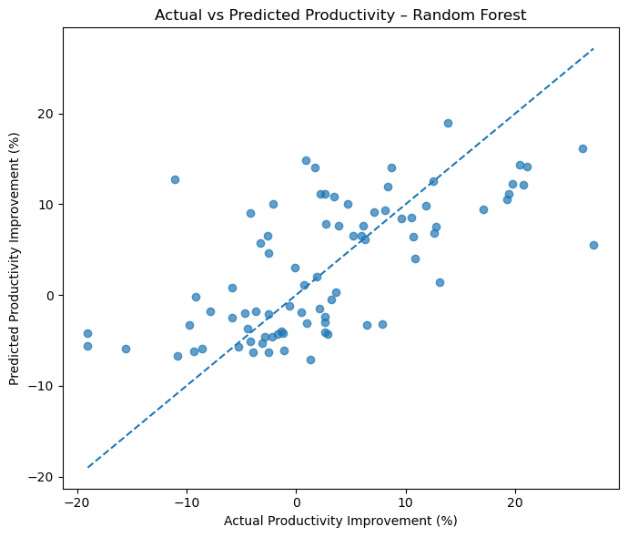

```
Saved: outputs\figures\Appendix_Figure_A3_Actual_vs_Predicted_Productivity.png
```

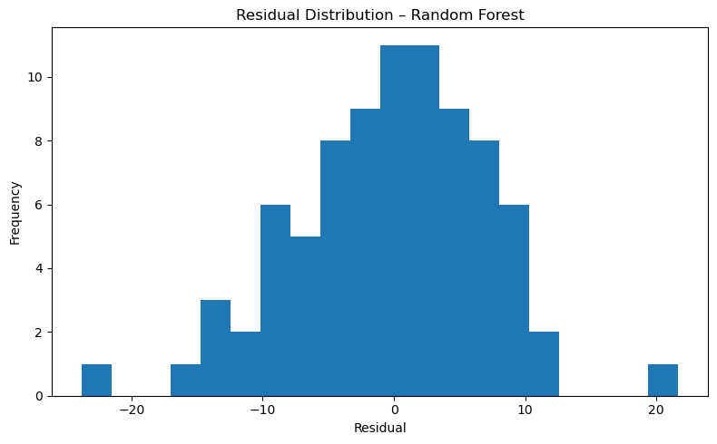

```
Saved: outputs\figures\Appendix_Figure_A4_Residual_Distribution.png
Selected model: Random Forest
Mean residual: -0.317
Residual standard deviation: 7.323
```

```python
best_model_name = model_results.loc[0, "Model"]
best_model = fitted_models[best_model_name]
best_predictions = test_predictions[best_model_name]
residuals = y_test - best_predictions

plt.figure(figsize=(7, 6))
plt.scatter(y_test, best_predictions, alpha=0.7)
minimum_value = min(y_test.min(), best_predictions.min())
maximum_value = max(y_test.max(), best_predictions.max())
plt.plot(
    [minimum_value, maximum_value],
    [minimum_value, maximum_value],
    linestyle="--",
)
plt.title(f"Actual vs Predicted Productivity – {best_model_name}")
plt.xlabel("Actual Productivity Improvement (%)")
plt.ylabel("Predicted Productivity Improvement (%)")
save_figure("Appendix_Figure_A3_Actual_vs_Predicted_Productivity.png")

plt.figure(figsize=(8, 5))
plt.hist(residuals, bins=20)
plt.title(f"Residual Distribution – {best_model_name}")
plt.xlabel("Residual")
plt.ylabel("Frequency")
save_figure("Appendix_Figure_A4_Residual_Distribution.png")

print(f"Selected model: {best_model_name}")
print(f"Mean residual: {residuals.mean():.3f}")
print(f"Residual standard deviation: {residuals.std():.3f}")
```

|  | Feature | Importance_Mean | Importance_SD |
| --- | --- | --- | --- |
| 0 | AI_Phase_Count | 0.403 | 0.092 |
| 1 | Baseline effort (Test Planning) | 0.023 | 0.010 |
| 2 | Baseline_Share_Test Execution | 0.020 | 0.015 |
| 3 | AI_Exposure_Automation Development | 0.014 | 0.011 |
| 4 | AI_Exposure_Test Design | 0.013 | 0.006 |
| 5 | Baseline effort (Defect Management) | 0.010 | 0.004 |
| 6 | AI_Exposure_Defect Management | 0.009 | 0.002 |
| 7 | Baseline_Share_Test Design | 0.007 | 0.002 |
| 8 | Application_Name | 0.006 | 0.006 |
| 9 | Baseline_Share_Automation Development | 0.004 | 0.003 |
| 10 | Total_Baseline_Effort | 0.003 | 0.002 |
| 11 | AI_Defect Management | 0.002 | 0.001 |
| 12 | AI_Automation Development | 0.002 | 0.003 |
| 13 | Baseline_Share_Test Planning | 0.001 | 0.004 |
| 14 | AI_Exposure_Regression Testing | 0.001 | 0.017 |

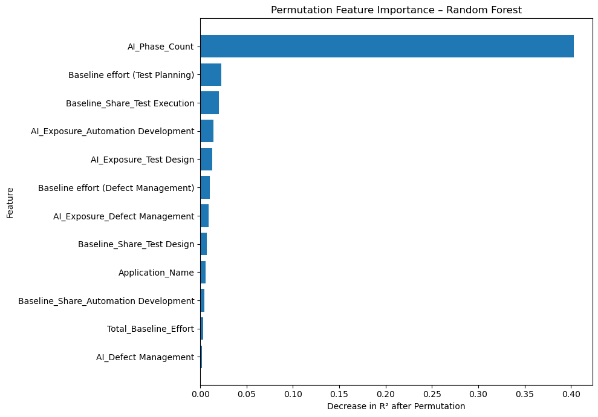

```
Saved: outputs\figures\Appendix_Figure_A5_Permutation_Feature_Importance.png
```

```python
importance_result = permutation_importance(
    best_model,
    X_test,
    y_test,
    n_repeats=5,
    random_state=42,
    scoring="r2",
    n_jobs=1,
)

feature_importance = (
    pd.DataFrame({
        "Feature": feature_columns,
        "Importance_Mean": importance_result.importances_mean,
        "Importance_SD": importance_result.importances_std,
    })
    .sort_values("Importance_Mean", ascending=False)
    .reset_index(drop=True)
)
display(feature_importance.head(15))
feature_importance.to_csv(
    TABLES_DIR / "Permutation_Feature_Importance.csv", index=False
)

top_features = feature_importance.head(12).sort_values("Importance_Mean")
plt.figure(figsize=(10, 7))
plt.barh(top_features["Feature"], top_features["Importance_Mean"])
plt.title(f"Permutation Feature Importance – {best_model_name}")
plt.xlabel("Decrease in R² after Permutation")
plt.ylabel("Feature")
save_figure("Appendix_Figure_A5_Permutation_Feature_Importance.png")
```

## 7. Interim Findings and Remaining Work

### Preliminary findings

- AI-assisted phase observations show substantially higher mean productivity improvement than traditional observations.
- The RQ1 difference is statistically significant and practically large.
- AI-derived value is phase-dependent rather than uniform.
- Regression Testing, Test Design, and Automation Development are the strongest preliminary priority areas.
- Random Forest provides the strongest grouped holdout performance, but the moderate R² means predictions should supplement managerial judgement.
- The evidence supports targeted adoption and controlled governance rather than blanket deployment.

### Remaining work for the final report

- Complete sensitivity and robustness checks.
- Review feature-importance stability across validation folds.
- Finalise the business adoption roadmap and governance recommendations.
- Add direct cost, quality, coverage, AI tool, and human-review variables when available.
- Publish the repository and insert the active GitHub URL into the report.